# RStudio, Git and GitHub

# Version Control

## Introduction

[figure not shown]

Source: “notFinal.doc” by Jorge Cham, https://www.phdcomics.com

- **Version Control** can be thought of as a recording of your progress: you can rewind to start at the base document and play back each change you made, eventually arriving at one of your more recent versions.
- In other words, we can “play” the different *versions* of the document of interest i.e. version control system is a tool that keeps track of our changes, effectively creating different *versions* of our files.
- Version control is useful, whether you are working alone or with a team.

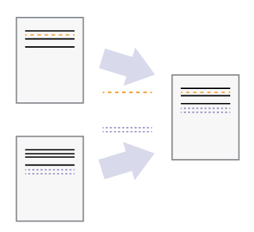

- Let us say that two users can make independent sets of changes on the same document. Unless there is a **conflict**, you can incorporate two sets of changes into the same base document.
- A conflict is a change made by one user of version control system that is incompatible with changes made by other users.
- Version control system requests human assistance where two people make conflicting edits.
- Version control allows us to decide which changes will be made to the next version (each record of these changes is called a **commit**), and keeps useful metadata about them.
- For any part of a document, you can determine when, why, and by whom it was ever edited.
- Each person edits his or her own copy of the documents and chooses when to share those changes with the rest of the team. Thus, temporary or partial edits by one person do not interfere with another person’s work.

### Summary

1. Version control is like an unlimited ‘undo’.
2. Version control also allows many people to work in parallel.

#### Git is a kind of version control system.

## Repositories and working copies

Version control uses - **Repository**: database of all edits or versions of your project. - **Working copy**: A personal copy of all the files in the project. You can make arbitrary edits to this copy, without affecting your teammates.

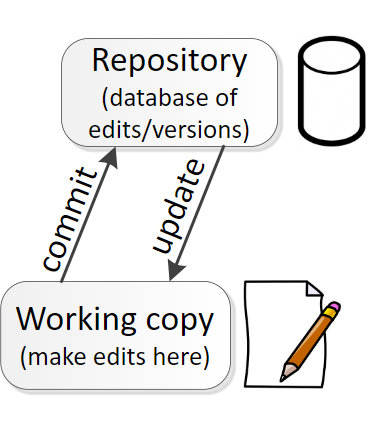

- When you are happy with your edits, you `commit` your changes to a repository.
- You can `update` your working copy to incorporate any new edits or versions that have been added to the repository since the last time you updated.
- If different users made edits simultaneously (this is sometimes called **branching**), the the version history splits and then merges again. In the example below, Version 4 is called a *merge*.

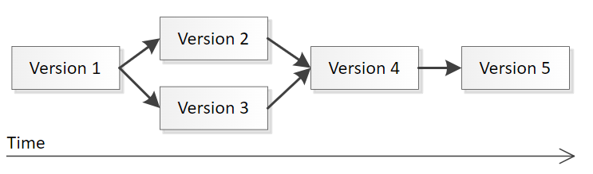

## Distributed and centralized Version Control

- There are two types of version control that mainly differ in the number of repositories:
  - Centralized version control: there is one repository
  - Distributed version control: there are multiple repositories.
- Distributed version control is more modern while centralized version control is rarely used these days.

#### Git, the most popular version control, is a distributed version control system.

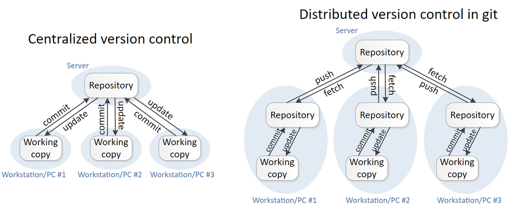

## References:

1. [Version control with Git](https://swcarpentry.github.io/git-novice/01-basics.html) by Software Carpentry.
2. [Version control concepts and best practices](https://homes.cs.washington.edu/~mernst/advice/version-control.html)